# Correlations between PAM & SGMA / MemoryLab’s Memory Index

Thomas Wilschut & Hedderik van Rijn

2025-01-27 - 2025-02-05

```r
# Load packages:
library(ggplot2)
library(dplyr)
library(lubridate)
library(patchwork)
library(ggcorrplot)
library(tidyr)
library(purrr)
library(psych)
library(lme4)
library(ggsignif)
library(glmnet)
library(knitr)
library(corrplot)
library(kableExtra)
library(readxl)
library(patchwork)
```

# 1 1 Load data

```r
dat <- read.csv('data/processed/summary_dat_corrected_mi')
pam <- read.csv('data/processed/uitdraai_pam.csv', sep = ';')

# Create a new participant id to merge the. If group is 'Recipient', this will be TR0xxxx, with the last three or four digits being the rec_id.
# If group is 'Donor', this will be TD0xxxx, with the last three or four digits being the dnr_id:

pam$rec_id <- ifelse(pam$group == "Recipient", paste0("TR0", pam$rec_id), paste0("TD0", pam$dnr_id))

# if the number of digits is after the letters is four (e.g., TR0644) we need to add a 0, e.g., TR00644:
pam$rec_id <- ifelse(nchar(pam$rec_id) == 6, paste0(substr(pam$rec_id, 1, 3), "0", substr(pam$rec_id, 4, 6)), pam$rec_id)

pam$deelnemerid <- pam$rec_id

# merge the data:
dat <- left_join(dat, pam, by = "deelnemerid")

# take the variables of interest
pam <- dat %>% dplyr::select(mi_raw, mi_demo_corrected, mi, mi_corrected, pam_edta, pam_units_edta, adm_gly_edta, bio_adm_edta, bmi.y, hba1_p_blo, crp_blo, group.x, age, npotscore15wtdl, nposcorefluencyanimal, nposcoretmta, algdat,)

# rename for clarity:
colnames(pam)[colnames(pam) == 'bmi.y'] <- 'bmi'
colnames(pam)[colnames(pam) == 'group.x'] <- 'group'

rm(dat)
```

Here, we will examine the relationship between levels of PAM (peptidylglycine-α-amidating monooxygenas) and memory function as measured by the MI. From PAM theragnostics website:’ PAM enzyme is the only known enzyme to catalyze the formation of c‑terminally amidated peptide hormones for gaining their biological activity. Already several decades ago, the connection between the diverse human pathologies and the level of α-amidation has been made. Thus, the increase of the PAM amidating activity could be directly linked to the presence or potential development of the medullary thyroid carcinoma, neuroendocrine and pancreatic endocrine tumors, insulin induced hypoglycemia, type 2 diabetes, multiple sclerosis, post-polio syndrome, diverse neural disfunction (Bousquet-Moore et al., 2010), hypertension (Shimosawa et al., 2000), Alzheimer´s disease (Wand et al. 1987) and many others.’ *This means that we would expect a negative relationship between PAM levels and memory function.*

The following variables of interest are available in the dataset:

- pam_edta: measured concentration of PAM in plasma samples collected using EDTA (a type of anticoagulant) in ng/mL (nanograms per milliliter).
- pam_units_edta: PAM activity in plasma samples collected using EDTA. This variable reflects the enzyme’s ability to modify peptides and is often used to assess PAM’s functional status. According to Jip, this is our main variable of interest.
- adm_gly_edta: concentration of adrenomedullin (ADM) in plasma samples, measured in EDTA plasma. Adrenomedullin is a peptide hormone involved in various physiological processes, including vasodilation (widening of blood vessels), and is commonly studied alongside PAM due to overlapping roles in vascular health and disease.
- bio_adm_edta: biologically active adrenomedullin (bio-ADM) levels in plasma samples, measured in EDTA plasma. Bio-ADM refers to the fraction of adrenomedullin that is biologically functional and capable of exerting its physiological effects (like vasodilation or influencing vascular integrity).

We also have access to variables that usually correlate strongly with vascular health and inflammation: bmi, hba1 and crp.

There are a few versions of the memory index we are testing here:

- mi_raw: the raw, uncorrected memory index.
- mi: the topic-difficulty corrected memory index.
- mi_demo_corrected: the memory index corrected for age, education, gender (but not topic)
- mi_corrected: the memory index corrected for age, education, and topic

Note that results should be similar for the mi_demo_corrected and mi_corrected.

# 2 Distributions and transformations

Check distributions of PAM, ADM and bio-ADM levels.

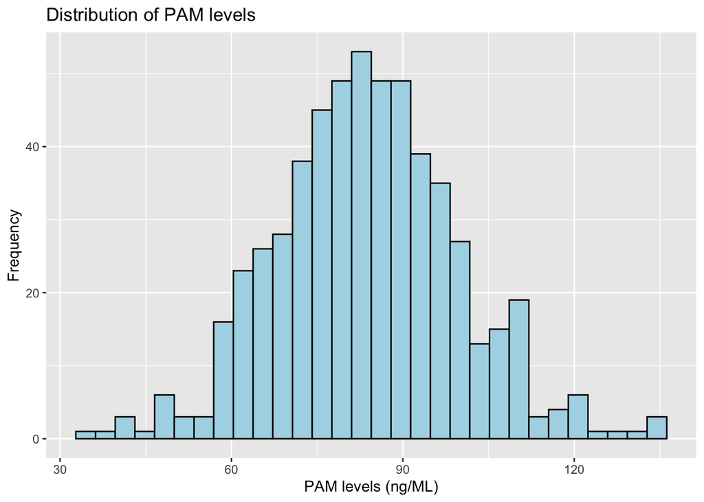

```r
# convert all but group to numeric:
pam <- pam %>% mutate(across(-c(group, algdat), as.numeric))

ggplot(pam, aes(x = pam_edta)) +
  geom_histogram(fill = "lightblue", color = "black", bins = 30) +
  labs(title = "Distribution of PAM levels",
       x = "PAM levels (ng/ML)",
       y = "Frequency")
```

PAM_edta seems normally distributed, so there is no need to transpose.

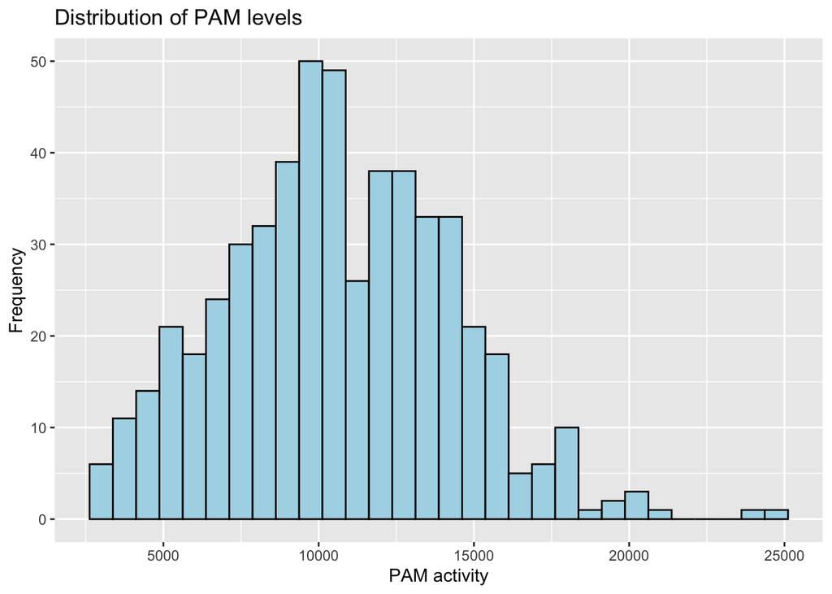

```r
ggplot(pam, aes(x = pam_units_edta)) +
  geom_histogram(fill = "lightblue", color = "black", bins = 30) +
  labs(title = "Distribution of PAM levels",
       x = "PAM activity",
       y = "Frequency")
```

The same seems to go for the ‘PAM_units_edta’ variable. Next, we will look at ADM levels:

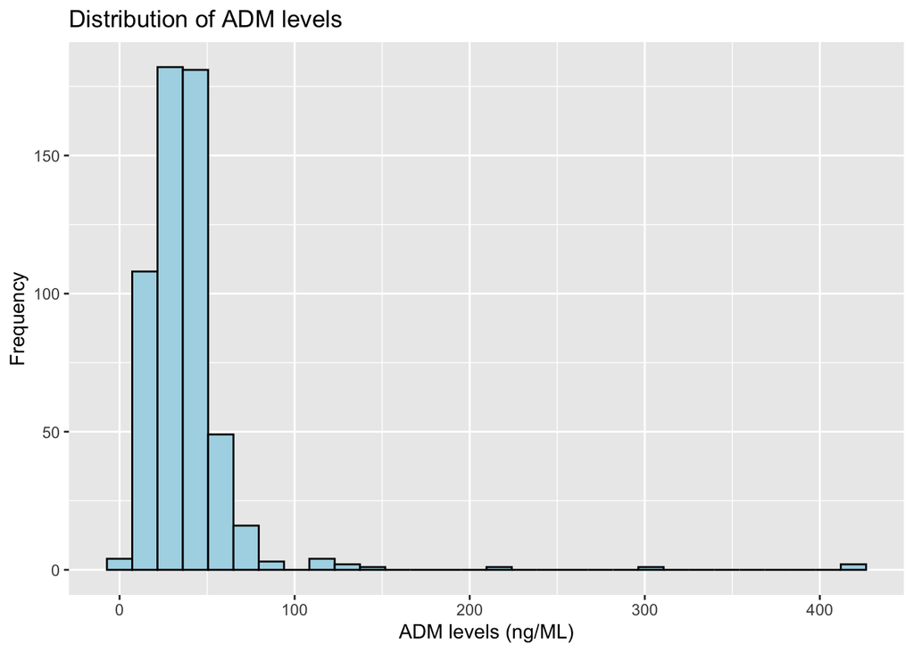

```r
ggplot(pam, aes(x = adm_gly_edta)) +
  geom_histogram(fill = "lightblue", color = "black", bins = 30) +
  labs(title = "Distribution of ADM levels",
       x = "ADM levels (ng/ML)",
       y = "Frequency")
```

```r
pam$adm_gly_edta <- log(pam$adm_gly_edta)
```

Let’s also look at bio-ADM:

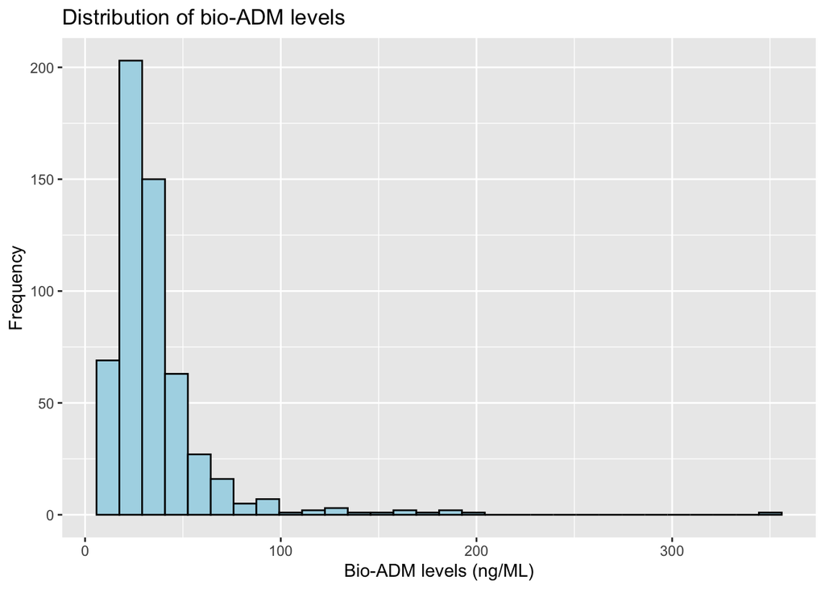

```r
ggplot(pam, aes(x = as.numeric(bio_adm_edta))) +
  geom_histogram(fill = "lightblue", color = "black", bins = 30) +
  labs(title = "Distribution of bio-ADM levels",
       x = "Bio-ADM levels (ng/ML)",
       y = "Frequency")
```

```r
pam$bio_adm_edta <- log(pam$bio_adm_edta)
```

# 3 Correlations

Next, we will look at the correlations with MI, across all participants and within the donor and recipient groups separately.

## 3.1 All participants

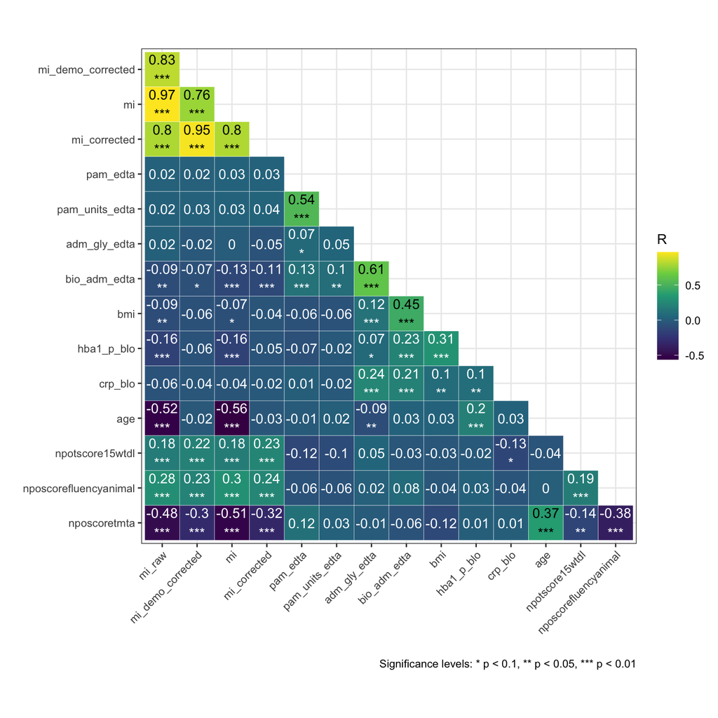

```r
donors <- pam %>% filter (group == 'donor') %>% dplyr::select(-group, -algdat)
recipients <- pam  %>% filter (group == 'receiver') %>% dplyr::select(-group, -algdat)
all <- pam %>% dplyr::select(-group, -algdat)

# all
correlations <- cor(all, use = "pairwise.complete.obs")
stats <- cor.mtest(all, conf.level = 0.95)

# wrap in a function

create_correlation_plot  <- function (corr) {
# create tile plot with sign stars:
nm = rownames(corr)
m = t(combn(nm, 2))
d = cbind(data.frame(m), R = corr[m], P = stats$p[m])
d$label = round(d$R, 2)

# add significance stars, based on the highest significance level:
d <- d %>% mutate(label = ifelse(P < 0.01, paste0(label, "\n***"), label))
d <- d %>% mutate(label = ifelse(P < 0.05 & P >= 0.01, paste0(label, "\n**"), label))
d <- d %>% mutate(label = ifelse(P < 0.1 & P >= 0.05, paste0(label, "\n*"), label))

d$X1 = factor(d$X1, nm)
d$X2 = factor(d$X2, rev(nm))

 p <- ggplot(d, aes(X1, X2, fill = R, label = label)) +
    geom_tile(color = "white") +
    scale_fill_viridis_c() +
    geom_text(color = ifelse(d$R > 0.35, "black", "white")) +
    theme_bw() +
  xlab("") +
  ylab("") +
  coord_equal() +
  theme(axis.text.x = element_text(angle = 45, hjust = 1)) +
  # star interpretation:
  labs(caption = "Significance levels: * p < 0.1, ** p < 0.05, *** p < 0.01")

 # return the plot:
 return(p)
       }


a <- create_correlation_plot(correlations)
a
```

The plot shows no significant correlations between PAM or PAM units and the MI. The raw MI shows a small significant correlation with bio-adm, but this effect is not significant in the demo-corrected MI

## 3.2 Donors

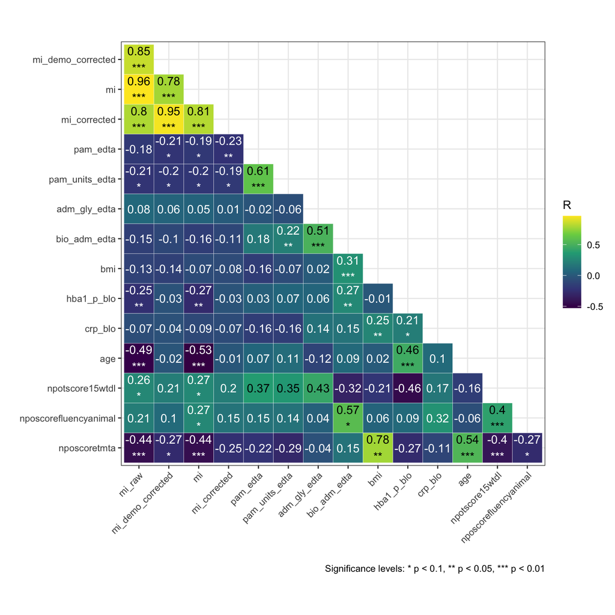

```r
correlations <- cor(donors, use = "pairwise.complete.obs")
stats <- cor.mtest(donors, conf.level = 0.95)

b <- create_correlation_plot(correlations)
b
```

Here, we do find a few correlations that reach significance. More specifically, PAM units seem to be negatively correlated with MI and with corrected MI. This means that higher PAM activity is associated with lower memory performance. This is in line with the literature, as PAM is often associated with vascular health and inflammation, which are known to negatively affect cognitive function. In addition, pam level seems to be negatively correlated with the corrected MI.

Let’s create a scatter plot to visualize this relationship:

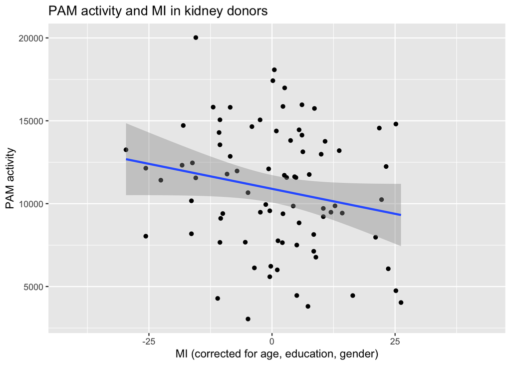

```r
ggplot(donors, aes(x = mi_demo_corrected, y = pam_units_edta)) +
  geom_point() +
  geom_smooth(method = "lm", se = TRUE) +
  labs(title = "PAM activity and MI in kidney donors",
       x = "MI (corrected for age, education, gender)",
       y = "PAM activity")
```

For how many donors do we have data?

```r
sum(!is.na(donors$pam_units_edta))
```

```
## [1] 80
```

And for how many recipients?

```r
sum(!is.na(recipients$pam_units_edta))
```

```
## [1] 451
```

We see that there is a negative trend, but there are only 80 observations (for which there are PAM unit values and MI scores) for donors, so we need to be careful with our interpretations.

## 3.3 Recipients

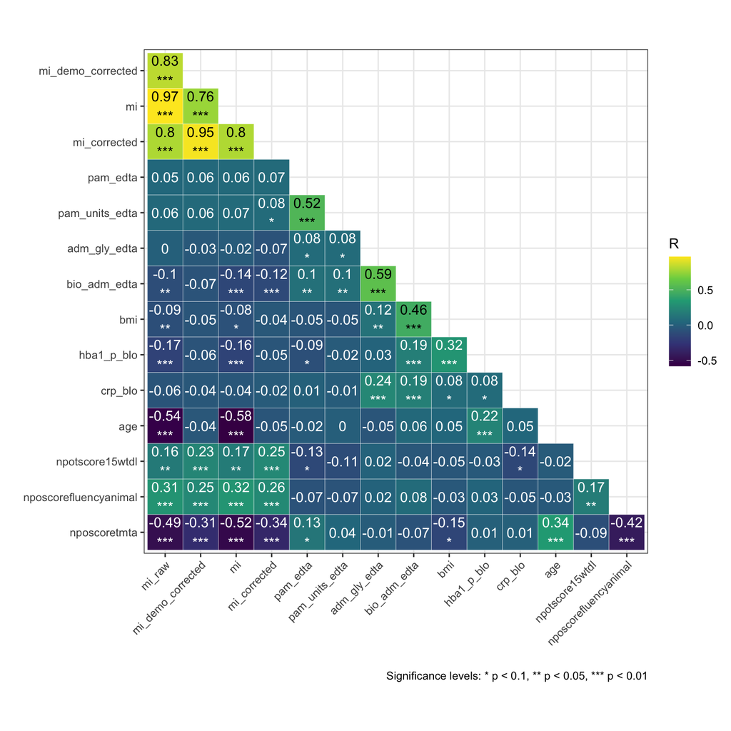

```r
# recipients
correlations <- cor(recipients, use = "pairwise.complete.obs")
stats <- cor.mtest(recipients, conf.level = 0.95)

c <- create_correlation_plot(correlations)
c
```

For recipients, we find no significant correlations between PAM or PAM units and the MI. There is a significant correlation between bio-ADM and the raw MI.

# 4 Time since lab

```r
# calculate the days since the lab measuremtns were taken:
pam$dat <- as.Date(pam$algdat, format = "%m-%d-%Y")
pam$days_elapsed <- as.numeric(Sys.Date() - pam$dat)
pam$years_elapsed <- round(pam$days_elapsed / 365)
```

Let’s look at the relationship between PAM activity and time since the lab measurements were taken, for PAM activity.

```r
# contrast code group:
pam$group <- factor(pam$group, levels = c("donor", "receiver"))
## Take care of the unbalanced number of cases in the groups:
pam$group_contrast <- ifelse(pam$group == "donor", mean(pam$group=="donor")/2, -(1-mean(pam$group=="donor"))/2)
# raw memory index:
m1 <- lm(pam_units_edta ~ mi_raw * group_contrast * years_elapsed, data = pam)
summary(m1)
```

```
##
## Call:
## lm(formula = pam_units_edta ~ mi_raw * group_contrast * years_elapsed,
##     data = pam)
##
## Residuals:
##     Min      1Q  Median      3Q     Max
## -9275.6 -2363.0  -193.5  2442.3 14195.5
##
## Coefficients:
##                                     Estimate Std. Error t value Pr(>|t|)
## (Intercept)                         23281.70    3992.77   5.831 9.66e-09 ***
## mi_raw                               -135.46      54.49  -2.486  0.01323 *
## group_contrast                      34519.84   13386.02   2.579  0.01019 *
## years_elapsed                       -2103.36     777.91  -2.704  0.00708 **
## mi_raw:group_contrast                -426.66     181.61  -2.349  0.01918 *
## mi_raw:years_elapsed                   21.73      10.73   2.025  0.04334 *
## group_contrast:years_elapsed        -5226.88    2566.24  -2.037  0.04217 *
## mi_raw:group_contrast:years_elapsed    62.29      35.23   1.768  0.07765 .
## ---
## Signif. codes:  0 '***' 0.001 '**' 0.01 '*' 0.05 '.' 0.1 ' ' 1
##
## Residual standard error: 3602 on 523 degrees of freedom
##   (617 observations deleted due to missingness)
## Multiple R-squared:  0.04754,    Adjusted R-squared:  0.0348
## F-statistic:  3.73 on 7 and 523 DF,  p-value: 0.0005944
```

The first model shows that there is an effect of MI on the PAM activity. We also see the inspected interaction between mi and years_elapsed, which is significant. This means that the relationship between PAM activity and MI becomes weaker (i.e., less negative) as the blood test has been completed a longer time ago.

Next, we see if we can predict the memory index using PAM activity:

```r
m2 <- lm(mi_raw ~ pam_units_edta * group_contrast * years_elapsed, data = pam)
summary(m2)
```

```
##
## Call:
## lm(formula = mi_raw ~ pam_units_edta * group_contrast * years_elapsed,
##     data = pam)
##
## Residuals:
##     Min      1Q  Median      3Q     Max
## -35.771 -12.990  -0.558  11.809  61.332
##
## Coefficients:
##                                               Estimate Std. Error t value
## (Intercept)                                  9.969e+01  1.126e+01   8.850
## pam_units_edta                              -2.136e-03  1.034e-03  -2.066
## group_contrast                               7.034e+01  3.912e+01   1.798
## years_elapsed                               -4.209e+00  2.144e+00  -1.964
## pam_units_edta:group_contrast               -6.941e-03  3.556e-03  -1.952
## pam_units_edta:years_elapsed                 3.515e-04  2.144e-04   1.640
## group_contrast:years_elapsed                -1.036e+01  7.245e+00  -1.430
## pam_units_edta:group_contrast:years_elapsed  1.009e-03  7.139e-04   1.413
##                                             Pr(>|t|)
## (Intercept)                                   <2e-16 ***
## pam_units_edta                                0.0393 *
## group_contrast                                0.0727 .
## years_elapsed                                 0.0501 .
## pam_units_edta:group_contrast                 0.0515 .
## pam_units_edta:years_elapsed                  0.1017
## group_contrast:years_elapsed                  0.1533
## pam_units_edta:group_contrast:years_elapsed   0.1583
## ---
## Signif. codes:  0 '***' 0.001 '**' 0.01 '*' 0.05 '.' 0.1 ' ' 1
##
## Residual standard error: 16.95 on 523 degrees of freedom
##   (617 observations deleted due to missingness)
## Multiple R-squared:  0.01893,    Adjusted R-squared:  0.005797
## F-statistic: 1.442 on 7 and 523 DF,  p-value: 0.1862
```

The effects are qualitatively similar, but weaker.

Next, we will do the same for the MI score that was corrected age, education, gender:

```r
# demo corrected memory index:
m3 <- lm(pam_units_edta ~ mi_demo_corrected * group_contrast * years_elapsed, data = pam)
summary(m3)
```

```
##
## Call:
## lm(formula = pam_units_edta ~ mi_demo_corrected * group_contrast *
##     years_elapsed, data = pam)
##
## Residuals:
##     Min      1Q  Median      3Q     Max
## -9582.9 -2371.4  -119.1  2409.7 14291.2
##
## Coefficients:
##                                                 Estimate Std. Error t value
## (Intercept)                                    13568.669    830.893  16.330
## mi_demo_corrected                                -79.675     69.735  -1.143
## group_contrast                                  3886.316   2833.039   1.372
## years_elapsed                                   -554.487    160.710  -3.450
## mi_demo_corrected:group_contrast                -320.870    233.414  -1.375
## mi_demo_corrected:years_elapsed                    9.573     13.013   0.736
## group_contrast:years_elapsed                    -795.274    537.500  -1.480
## mi_demo_corrected:group_contrast:years_elapsed    33.251     42.962   0.774
##                                                Pr(>|t|)
## (Intercept)                                     < 2e-16 ***
## mi_demo_corrected                              0.253754
## group_contrast                                 0.170719
## years_elapsed                                  0.000605 ***
## mi_demo_corrected:group_contrast               0.169820
## mi_demo_corrected:years_elapsed                0.462264
## group_contrast:years_elapsed                   0.139588
## mi_demo_corrected:group_contrast:years_elapsed 0.439300
## ---
## Signif. codes:  0 '***' 0.001 '**' 0.01 '*' 0.05 '.' 0.1 ' ' 1
##
## Residual standard error: 3616 on 523 degrees of freedom
##   (617 observations deleted due to missingness)
## Multiple R-squared:  0.03995,    Adjusted R-squared:  0.0271
## F-statistic: 3.109 on 7 and 523 DF,  p-value: 0.003188
```

The effect of the MI on PAM activity is not significant anymore, and the effect of years_elapsed becomes stronger. This seems to suggest that the raw memory index was capturing part of the effect of years_elapsed on PAM activity, while the demo_corrected MI is not capturing this effect.

Run the model with MI as dependent variable:

```r
m4 <- lm(mi_demo_corrected ~ pam_units_edta * group_contrast * years_elapsed, data = pam)
summary(m4)
```

```
##
## Call:
## lm(formula = mi_demo_corrected ~ pam_units_edta * group_contrast *
##     years_elapsed, data = pam)
##
## Residuals:
##     Min      1Q  Median      3Q     Max
## -31.201  -9.483  -0.412   8.673  49.327
##
## Coefficients:
##                                               Estimate Std. Error t value
## (Intercept)                                  6.034e+00  8.912e+00   0.677
## pam_units_edta                              -3.635e-04  8.180e-04  -0.444
## group_contrast                               2.525e+01  3.095e+01   0.816
## years_elapsed                               -2.794e-01  1.696e+00  -0.165
## pam_units_edta:group_contrast               -2.085e-03  2.813e-03  -0.741
## pam_units_edta:years_elapsed                -1.380e-06  1.696e-04  -0.008
## group_contrast:years_elapsed                -8.624e-01  5.732e+00  -0.150
## pam_units_edta:group_contrast:years_elapsed  3.240e-05  5.648e-04   0.057
##                                             Pr(>|t|)
## (Intercept)                                    0.499
## pam_units_edta                                 0.657
## group_contrast                                 0.415
## years_elapsed                                  0.869
## pam_units_edta:group_contrast                  0.459
## pam_units_edta:years_elapsed                   0.994
## group_contrast:years_elapsed                   0.880
## pam_units_edta:group_contrast:years_elapsed    0.954
##
## Residual standard error: 13.41 on 523 degrees of freedom
##   (617 observations deleted due to missingness)
## Multiple R-squared:  0.009431,   Adjusted R-squared:  -0.003828
## F-statistic: 0.7113 on 7 and 523 DF,  p-value: 0.6625
```

We find no significant results anymore.

# 5 Patterns in the data

There seem to be strong effects of years_elapsed. Is that something to take into account?

Let’s check for a relationship between age at the moment of MI test, and the years since the lab measurements were taken:

```r
cor.test(pam$age, pam$years_elapsed)
```

```
##
##  Pearson's product-moment correlation
##
## data:  pam$age and pam$years_elapsed
## t = 0.93303, df = 559, p-value = 0.3512
## alternative hypothesis: true correlation is not equal to 0
## 95 percent confidence interval:
##  -0.04349161  0.12181673
## sample estimates:
##        cor
## 0.03943237
```

There seems to be no effect on age of the number of years elapsed since the bloodsample was taken. (Which could reflect that more recently taken samples are older/younger participants.)

Is there a correlation between PAM activity and the age of the test?

```r
cor.test(pam$years_elapsed, pam$pam_units_edta)
```

```
##
##  Pearson's product-moment correlation
##
## data:  pam$years_elapsed and pam$pam_units_edta
## t = -3.7398, df = 529, p-value = 0.0002043
## alternative hypothesis: true correlation is not equal to 0
## 95 percent confidence interval:
##  -0.24227302 -0.07644506
## sample estimates:
##        cor
## -0.1604913
```

And just for the donors?

```r
donors <- pam %>% filter(group == 'donor')
cor.test(donors$years_elapsed, donors$pam_units_edta)
```

```
##
##  Pearson's product-moment correlation
##
## data:  donors$years_elapsed and donors$pam_units_edta
## t = -2.8158, df = 78, p-value = 0.006159
## alternative hypothesis: true correlation is not equal to 0
## 95 percent confidence interval:
##  -0.49072352 -0.09005105
## sample estimates:
##        cor
## -0.3037579
```

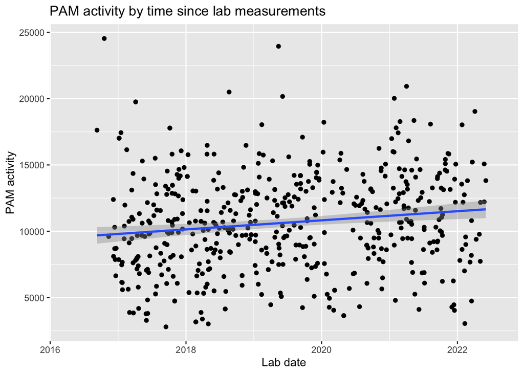

```r
ggplot(pam, aes(x = dat, y = pam_units_edta)) +
  geom_point() +
  geom_smooth(method = "lm", se = TRUE) +
  labs(title = "PAM activity by time since lab measurements",
       x = "Lab date",
       y = "PAM activity")
```

Let’s see if we can visualize the relationship between PAM activity and MI, as a function of the time since the lab measurement, to get a better idea of what is going on.

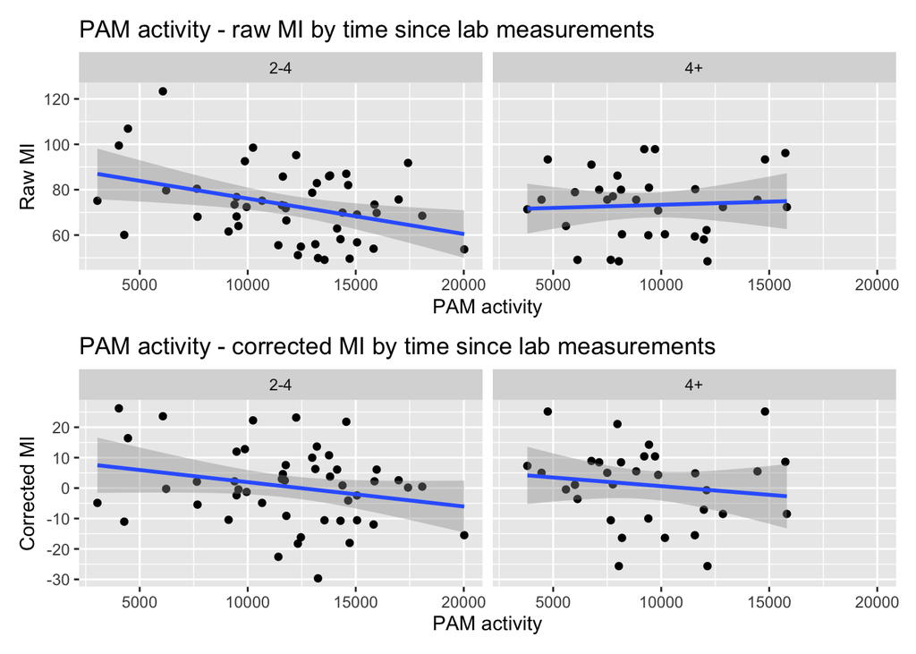

```r
# create a 'years elapsed group':
pam$years_elapsed_group <- cut(pam$years_elapsed, breaks = c(0, 4, Inf), labels = c('2-4', '4+'))

a <- ggplot(pam %>% filter (group == 'donor' & !is.na(years_elapsed_group)), aes(x = pam_units_edta, y = mi_raw)) +
  geom_point() +
  geom_smooth(method = "lm", se = TRUE) +
  facet_wrap(~years_elapsed_group) +
  labs(title = "PAM activity - raw MI by time since lab measurements",
       x = "PAM activity",
       y = "Raw MI")

b <- ggplot(pam %>% filter (group == 'donor' & !is.na(years_elapsed_group)), aes(x = pam_units_edta, y = mi_demo_corrected)) +
  geom_point() +
  geom_smooth(method = "lm", se = TRUE) +
  facet_wrap(~years_elapsed_group) +
  labs(title = "PAM activity - corrected MI by time since lab measurements",
       x = "PAM activity",
       y = "Corrected MI")

a / b
```

It seems like the later measurements show a weaker correlation, both for the corrected MI and the raw MI. Let’s run a final model, where we only consider the donors that had their blood drawn 2-4 years ago:

```r
m6 <- lm(mi_raw ~ pam_units_edta, data = pam %>% filter(group == 'donor' & years_elapsed_group == '2-4'))
summary(m6)
```

```
##
## Call:
## lm(formula = mi_raw ~ pam_units_edta, data = pam %>% filter(group ==
##     "donor" & years_elapsed_group == "2-4"))
##
## Residuals:
##     Min      1Q  Median      3Q     Max
## -24.931 -11.698  -0.502  11.906  41.126
##
## Coefficients:
##                  Estimate Std. Error t value Pr(>|t|)
## (Intercept)    91.7035870  7.1977843  12.741  < 2e-16 ***
## pam_units_edta -0.0015605  0.0005787  -2.697  0.00976 **
## ---
## Signif. codes:  0 '***' 0.001 '**' 0.01 '*' 0.05 '.' 0.1 ' ' 1
##
## Residual standard error: 15.13 on 46 degrees of freedom
## Multiple R-squared:  0.1365, Adjusted R-squared:  0.1177
## F-statistic: 7.272 on 1 and 46 DF,  p-value: 0.009756
```

```r
## Change the next analysis to one sided:
m7 <- lm(mi_demo_corrected ~ pam_units_edta, data = pam %>% filter(group == 'donor' & years_elapsed_group == '2-4'))
summary(m7)
```

```
##
## Call:
## lm(formula = mi_demo_corrected ~ pam_units_edta, data = pam %>%
##     filter(group == "donor" & years_elapsed_group == "2-4"))
##
## Residuals:
##      Min       1Q   Median       3Q      Max
## -29.0074  -9.2519   0.8608   7.8111  23.4959
##
## Coefficients:
##                  Estimate Std. Error t value Pr(>|t|)
## (Intercept)     9.9473570  5.8582097   1.698   0.0963 .
## pam_units_edta -0.0007997  0.0004710  -1.698   0.0963 .
## ---
## Signif. codes:  0 '***' 0.001 '**' 0.01 '*' 0.05 '.' 0.1 ' ' 1
##
## Residual standard error: 12.32 on 46 degrees of freedom
## Multiple R-squared:  0.05897,    Adjusted R-squared:  0.03851
## F-statistic: 2.883 on 1 and 46 DF,  p-value: 0.0963
```

The raw MI is significant, the corrected MI would be significant if tested one-sided (which would be reasonable given the clear hypothesis), but not in the “default” two-sided manner.